```python
%load_ext load_style
%load_style talk.css
```

```
The load_style extension is already loaded. To reload it, use:
  %reload_ext load_style
```

# What is IPython and the IPython notebook ?

[IPython](http://ipython.org/) is a enhanced Python shell giving many niceties (interactive help, code introspection, etc)

The [IPython notebook](http://ipython.org/notebook.html) is a Web Notebook (running in the browser) connected to an IPython engine

From the website:

```
The IPython Notebook is a web-based interactive computational environment where you can combine code execution, text, mathematics, plots and rich media into a single document
```

### executable code

```python
### This is a code cell, containing python code, it is executed by <shift>-<enter> or <alt>-<enter>

def func(x):
    return x**2

[func(x) for x in xrange(10)]
```

```
[0, 1, 4, 9, 16, 25, 36, 49, 64, 81]
```

```python
%matplotlib inline
```

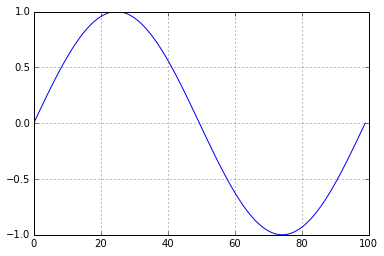

```python
import numpy as np
import matplotlib.pyplot as plt
t = np.linspace(0, 2*np.pi, 100)
plt.plot(np.sin(t))
plt.grid()
```

### [Markdown](http://daringfireball.net/projects/markdown/) cell

This is a **markdown** cell, I can [link to stuff](http://daringfireball.net/projects/markdown/), make lists

- one item
- anoter item

and more generally use all [Markdown syntax](http://daringfireball.net/projects/markdown/syntax) elements

I can also embed images such as this one directly into the cell, and if needed can use straight HTML tags

[figure not shown]

this is an image

Thanks to MathJax, you can include mathematical expressions in a markdown cell using Latex syntax both inline and displayed:

For example `$e^{i\pi} + 1 = 0$` becomes $e^{i\pi} + 1 = 0$

and

`$$e^x=\sum_{i=0}^\infty \frac{1}{i!}x^i$$`

becomes:

$e^x=\sum_{i=0}^\infty \frac{1}{i!}x^i$

You can also do much more, if interested into the **IPython notebook** you can check out [my github repository](https://github.com/nicolasfauchereau/NIWA_Python_seminars) especially [this section](http://nbviewer.ipython.org/github/nicolasfauchereau/NIWA_Python_seminars/blob/master/1_Overview_IPython.ipynb)

## A short demo of the IPython notebook widgets

```python
from IPython.html.widgets import interact, fixed
from IPython.html import widgets
```

### simple function that just prints its argument

```python
def f(x):
    print(x)
```

### if x is a integer, a widget slider will be created

```python
interact(f, x=10);
```

```
13
```

#### you can also use a python `decorator` syntax

```python
@interact(x=2)
def f(x):
    print(x)
```

```
0
```

### If x is Boolean (True / False), a checkbox is created

```python
interact(f, x=True);
```

```
True
```

### If x is a string: text box

```python
interact(f, x='Hi there!');
```

```
hello here
```

### Widgets can be called with arguments to customize them

```python
interact(f, x=widgets.IntSliderWidget(min=-20,max=40,step=2,value=10));
```

```
38
```

### And you can completely override the defaults widget by defining what you want

```python
interact(f, x=widgets.DropdownWidget(
    values=range(1,10),
    value=2
));
```

```
8
```

### An example with plot

```python
import pandas as pd
```

see the [Pandas website](http://pandas.pydata.org) for more info on Pandas

#### 2 variables: just random gaussian noise

```python
xdf = pd.DataFrame(np.random.normal(size=(100,2)), columns=['A','B'])
```

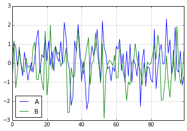

```python
xdf.plot()
```

```python
def plot_x(x, variable='A'):
    f, ax = plt.subplots(figsize=(10,5))
    x[variable].plot(ax=ax, label=variable, lw=2)
    ax.set_ylim(-3, 3)
    plt.legend()
    plt.show()
```

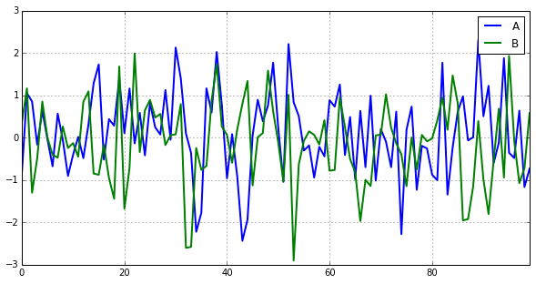

```python
interact(plot_x, x=fixed(xdf), variable=widgets.SelectWidget(
    #values=['A','B', ['A','B']]
    values={'A': 'A', 'B': 'B', 'A and B': ['A','B']}, value=['A','B']
));
```

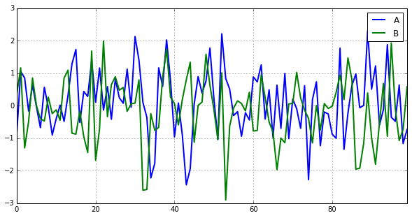

```python
interact(plot_x, x=fixed(xdf), variable=widgets.RadioButtonsWidget(
    values={'A': 'A', 'B': 'B', 'A and B': ['A','B']}, value=['A','B']
));
```